# IS606 - Presentation -Chapter 6

Kishore Prasad

March 23, 2016

In this session we will look at the following problem

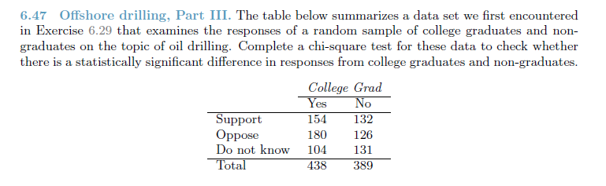

**Solution:**

To check whether there is a statistically significant difference between the Grads and Non-Grads, we form the following hypotheses:

H<sub>0</sub>: There is no difference in support between the 2 groups.

H<sub>A</sub>: There is a difference in support between the 2 groups.

Lets first calculate the row totals and change the layout of the table.

| College Grad | Yes | No | Total |
| --- | --- | --- | --- |
| Support | 154 | 132 | 286 |
| oppose | 180 | 126 | 306 |
| Do Not Know | 104 | 131 | 235 |
| Total | 438 | 389 | 827 |

Next we calculate the expected count for each cell. The expected count for each cell is calculated with the following formula:

Expected count <sub>row</sub> <sub>i,</sub> <sub>col</sub> <sub>j</sub> = $\frac{(row ~i~ total, col ~j~ total)} {(table total)}$

Using the above formula for each cell, we get the following expected counts table:

| College Grad | Yes | No |
| --- | --- | --- |
| Support | 151.5 | 134.5 |
| oppose | 162.1 | 143.9 |
| Do Not Know | 124.5 | 110.5 |

Next we calculate the following formula for each cell:

$\frac{(Observed count~i,j~ - expected count~i,j~)^2} {(expected count~i,j)}$

Using the above formula, we get the following table:

| College Grad | Yes | No |
| --- | --- | --- |
| Support | 0.04 | 0.05 |
| oppose | 1.98 | 2.23 |
| Do Not Know | 3.36 | 3.79 |

The chi-square statistic is calculated by summing up all the values in the above table.

The degrees of freedom is calculated using the following formula:

df = (rows - 1) x (cols - 1)

$df = 2$